# 20201023_saijou

```python
import numpy as np
import matplotlib.pyplot as plt
import pandas as pd

df = pd.read_excel('Supplemental_Table_S2.xls')
df
```

|  | Cell | Antibody | total read number | nonredundant read | redundant read | complexity | depth | Genome coverage | GC | FRiP (MACS2) | ... | SSP-RSC | Background uniformity | FCS | Q-RSC | JSD | PPQT-NSC | PPQT-RSC | PPQT-Qtag | MACS2 peaks | DROMPA peaks |
| --- | --- | --- | --- | --- | --- | --- | --- | --- | --- | --- | --- | --- | --- | --- | --- | --- | --- | --- | --- | --- | --- |
| 0 | E003 | H3K27ac | 21502554 | 21391238 (99.5%) | 111316 (0.5%) | 0.998 | 1.26 | 0.68 | 49 | 0.2021 | ... | 1.363140 | 1.09253 | 0.496900 | 1.742 | 0.360201 | 1.221092 | 1.526650 | 2.0 | 68611 | 22397 |
| 1 | E004 | H3K27ac | 30000000 | 29706394 (99.0%) | 293606 (1.0%) | 0.997 | 1.75 | 0.74 | 52 | 0.2090 | ... | 1.184260 | 1.06470 | 0.431716 | 1.394 | 0.367367 | 1.168355 | 1.281552 | 1.0 | 78944 | 23341 |
| 2 | E005 | H3K27ac | 30000000 | 29698612 (99.0%) | 301388 (1.0%) | 0.997 | 1.75 | 0.74 | 51 | 0.1965 | ... | 1.098210 | 1.04263 | 0.445636 | 1.190 | 0.362768 | 1.157160 | 1.084254 | 1.0 | 68912 | 21516 |
| 3 | E006 | H3K27ac | 30000000 | 29744493 (99.1%) | 255507 (0.9%) | 0.997 | 1.75 | 0.76 | 50 | 0.2292 | ... | 1.203240 | 1.09318 | 0.454843 | 1.435 | 0.362597 | 1.180057 | 1.327205 | 1.0 | 81094 | 26560 |
| 4 | E007 | H3K27ac | 30000000 | 29623085 (98.7%) | 376915 (1.3%) | 0.995 | 1.75 | 0.80 | 49 | 0.0637 | ... | 1.049670 | 1.10472 | 0.234771 | 1.084 | 0.276481 | 1.070251 | 0.924231 | 0.0 | 25710 | 7510 |
| ... | ... | ... | ... | ... | ... | ... | ... | ... | ... | ... | ... | ... | ... | ... | ... | ... | ... | ... | ... | ... | ... |
| 855 | E125 | Input | 30000000 | 30000000 (100.0%) | 0 (0.0%) | 1 | 1.77 | 0.87 | 45 | 0.0013 | ... | 0.957233 | 1.14108 | 0.039721 | 0.920 | 0.212654 | 1.016054 | 0.857049 | 0.0 | 379 | 744 |
| 856 | E126 | Input | 16806474 | 16806474 (100.0%) | 0 (0.0%) | 1 | 0.99 | 0.70 | 45 | 0.0042 | ... | 1.141200 | 1.15005 | 0.152653 | 1.234 | 0.233434 | 1.066987 | 1.197045 | 1.0 | 836 | 2008 |
| 857 | E127 | Input | 20364549 | 20364549 (100.0%) | 0 (0.0%) | 1 | 1.20 | 0.80 | 45 | 0.0037 | ... | 0.485702 | 1.15766 | 0.204078 | 0.850 | 0.210048 | 1.012264 | 0.268751 | -1.0 | 550 | 2092 |
| 858 | E128 | Input | 12868984 | 12868984 (100.0%) | 0 (0.0%) | 1 | 0.76 | 0.66 | 45 | 0.0029 | ... | 0.407191 | 1.14904 | 0.146981 | 0.860 | 0.210967 | 1.013456 | 0.238210 | -2.0 | 335 | 8823 |
| 859 | E129 | Input | 30000000 | 30000000 (100.0%) | 0 (0.0%) | 1 | 1.77 | 0.88 | 43 | 0.0017 | ... | 0.699353 | 1.13843 | 0.057480 | 0.887 | 0.206593 | 1.011365 | 0.543952 | 0.0 | 410 | 866 |

860 rows × 22 columns

```python
grouped = df.groupby('Antibody')
grouped.mean()
```

| Antibody | total read number | depth | Genome coverage | GC | FRiP (MACS2) | FRiP (DROMPA) | SSP-NSC | SSP-RSC | Background uniformity | FCS | Q-RSC | JSD | PPQT-NSC | PPQT-RSC | PPQT-Qtag | MACS2 peaks | DROMPA peaks |
| --- | --- | --- | --- | --- | --- | --- | --- | --- | --- | --- | --- | --- | --- | --- | --- | --- | --- |
| H3K27ac | 2.384815e+07 | 1.398776 | 0.614592 | 48.867347 | 0.335627 | 0.263551 | 10.628491 | 1.234265 | 0.995833 | 0.480609 | 1.588031 | 0.429483 | 1.334308 | 1.380666 | 1.156250 | 77635.040816 | 28135.693878 |
| H3K27me3 | 2.596955e+07 | 1.527559 | 0.731969 | 48.622047 | 0.200243 | 0.052395 | 3.001507 | 1.000363 | 1.067237 | 0.218120 | 1.145181 | 0.313905 | 1.046741 | 0.948663 | 0.370079 | 64326.496063 | 8179.874016 |
| H3K36me3 | 2.629578e+07 | 1.546929 | 0.681732 | 47.322835 | 0.360702 | 0.075709 | 2.878950 | 0.968197 | 1.009111 | 0.207656 | 1.023307 | 0.367337 | 1.043242 | 0.837057 | 0.173228 | 73186.866142 | 25472.173228 |
| H3K4me1 | 2.635078e+07 | 1.549055 | 0.645748 | 49.370079 | 0.292206 | 0.122170 | 3.958322 | 1.110394 | 1.012135 | 0.221832 | 1.269055 | 0.396918 | 1.100633 | 1.164169 | 0.889764 | 146738.039370 | 29781.204724 |
| H3K4me3 | 2.496305e+07 | 1.456614 | 0.650945 | 48.212598 | 0.356109 | 0.316061 | 17.431514 | 1.142460 | 1.026362 | 0.567865 | 1.291717 | 0.452481 | 1.580844 | 1.182446 | 0.921260 | 39963.314961 | 21664.724409 |
| H3K9me3 | 2.558495e+07 | 1.502205 | 0.747717 | 46.992126 | 0.168276 | 0.026432 | 2.426743 | 0.737924 | 1.087738 | 0.203583 | 0.911780 | 0.289295 | 1.044851 | 0.508917 | -0.614173 | 73990.716535 | 9008.362205 |
| Input | 2.638445e+07 | 1.553622 | 0.826850 | 45.291339 | 0.003821 | 0.013376 | 1.451826 | 0.868197 | 1.135877 | 0.068045 | 1.119764 | 0.213490 | 1.020571 | 0.736335 | -0.440945 | 2059.976378 | 12303.070866 |

```python
# ２つ（以上）の属性でgroup化する場合
grouped = df.groupby(['Antibody', 'Cell'])
grouped.mean()
```

| Antibody | Cell | total read number | depth | Genome coverage | GC | FRiP (MACS2) | FRiP (DROMPA) | SSP-NSC | SSP-RSC | Background uniformity | FCS | Q-RSC | JSD | PPQT-NSC | PPQT-RSC | PPQT-Qtag | MACS2 peaks | DROMPA peaks |
| --- | --- | --- | --- | --- | --- | --- | --- | --- | --- | --- | --- | --- | --- | --- | --- | --- | --- | --- |
| H3K27ac | E003 | 21502554 | 1.26 | 0.68 | 49 | 0.2021 | 0.1413 | 5.73283 | 1.363140 | 1.09253 | 0.496900 | 1.742 | 0.360201 | 1.221092 | 1.526650 | 2.0 | 68611 | 22397 |
|  | E004 | 30000000 | 1.75 | 0.74 | 52 | 0.2090 | 0.1310 | 4.64490 | 1.184260 | 1.06470 | 0.431716 | 1.394 | 0.367367 | 1.168355 | 1.281552 | 1.0 | 78944 | 23341 |
|  | E005 | 30000000 | 1.75 | 0.74 | 51 | 0.1965 | 0.1262 | 4.51882 | 1.098210 | 1.04263 | 0.445636 | 1.190 | 0.362768 | 1.157160 | 1.084254 | 1.0 | 68912 | 21516 |
|  | E006 | 30000000 | 1.75 | 0.76 | 50 | 0.2292 | 0.1535 | 5.10641 | 1.203240 | 1.09318 | 0.454843 | 1.435 | 0.362597 | 1.180057 | 1.327205 | 1.0 | 81094 | 26560 |
|  | E007 | 30000000 | 1.75 | 0.80 | 49 | 0.0637 | 0.0365 | 2.34070 | 1.049670 | 1.10472 | 0.234771 | 1.084 | 0.276481 | 1.070251 | 0.924231 | 0.0 | 25710 | 7510 |
| ... | ... | ... | ... | ... | ... | ... | ... | ... | ... | ... | ... | ... | ... | ... | ... | ... | ... | ... |
| Input | E125 | 30000000 | 1.77 | 0.87 | 45 | 0.0013 | 0.0041 | 1.36131 | 0.957233 | 1.14108 | 0.039721 | 0.920 | 0.212654 | 1.016054 | 0.857049 | 0.0 | 379 | 744 |
|  | E126 | 16806474 | 0.99 | 0.70 | 45 | 0.0042 | 0.0115 | 2.41203 | 1.141200 | 1.15005 | 0.152653 | 1.234 | 0.233434 | 1.066987 | 1.197045 | 1.0 | 836 | 2008 |
|  | E127 | 20364549 | 1.20 | 0.80 | 45 | 0.0037 | 0.0118 | 1.48517 | 0.485702 | 1.15766 | 0.204078 | 0.850 | 0.210048 | 1.012264 | 0.268751 | -1.0 | 550 | 2092 |
|  | E128 | 12868984 | 0.76 | 0.66 | 45 | 0.0029 | 0.0123 | 1.42176 | 0.407191 | 1.14904 | 0.146981 | 0.860 | 0.210967 | 1.013456 | 0.238210 | -2.0 | 335 | 8823 |
|  | E129 | 30000000 | 1.77 | 0.88 | 43 | 0.0017 | 0.0047 | 1.30674 | 0.699353 | 1.13843 | 0.057480 | 0.887 | 0.206593 | 1.011365 | 0.543952 | 0.0 | 410 | 866 |

860 rows × 17 columns

```python
grouped = df.groupby('Antibody')
grouped["SSP-NSC"].describe()
```

| Antibody | count | mean | std | min | 25% | 50% | 75% | max |
| --- | --- | --- | --- | --- | --- | --- | --- | --- |
| H3K27ac | 98.0 | 10.628491 | 7.187384 | 1.47458 | 4.726793 | 8.85960 | 16.109950 | 36.74470 |
| H3K27me3 | 127.0 | 3.001507 | 2.275501 | 1.40126 | 1.775215 | 2.13453 | 2.853655 | 12.89230 |
| H3K36me3 | 127.0 | 2.878950 | 0.857118 | 1.44237 | 2.217845 | 2.76327 | 3.445625 | 6.33647 |
| H3K4me1 | 127.0 | 3.958322 | 2.075257 | 1.74950 | 2.658055 | 3.39133 | 4.417200 | 12.68960 |
| H3K4me3 | 127.0 | 17.431514 | 12.691163 | 1.90685 | 7.329880 | 14.35650 | 24.263200 | 74.84710 |
| H3K9me3 | 127.0 | 2.426743 | 0.870322 | 1.48843 | 1.747070 | 2.12857 | 2.901935 | 5.60866 |
| Input | 127.0 | 1.451826 | 0.398561 | 1.17248 | 1.243730 | 1.30674 | 1.506045 | 4.41231 |

```python
grouped["SSP-NSC"].describe("count")
```

```
---------------------------------------------------------------------------
TypeError                                 Traceback (most recent call last)
<ipython-input-106-c96b2b479f5a> in <module>
----> 1 grouped["SSP-NSC"].describe("count")

TypeError: describe() takes 1 positional argument but 2 were given
```

## 作図の例 (SSP-NSC)

### 棒グラフ (bar plot)

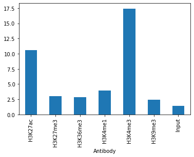

```python
grouped = df.groupby('Antibody')
group_nsc = grouped["SSP-NSC"]
group_nsc.mean().plot.bar()
```

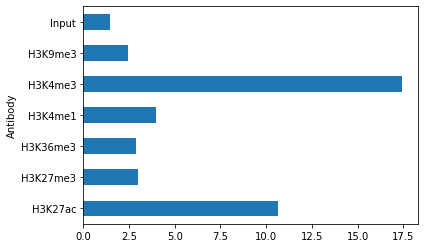

```python
# 横棒グラフ
group_nsc.mean().plot(kind='barh')
```

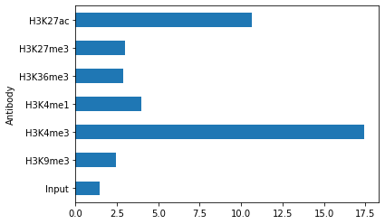

```python
# y軸を逆順に
ax = group_nsc.mean().plot(kind='barh')
ax.invert_yaxis()
```

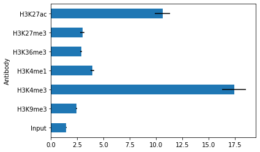

```python
# エラーバーを表示
sem = group_nsc.std()/np.sqrt(group_nsc.count())
ax = group_nsc.mean().plot(kind='barh', xerr=sem)
ax.invert_yaxis()
```

### 箱ひげ図 (box plot)

四分位点、最大値、最小値、外れ値を表示する。

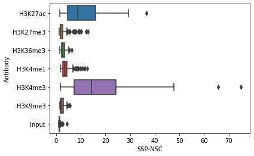

```python
# (seaborn利用)
import seaborn as sns
sns.boxplot(data=df, x='SSP-NSC', y='Antibody')
```

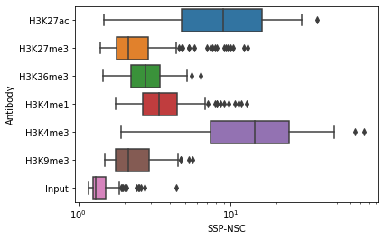

```python
# scaleをlogに
f, ax = plt.subplots(figsize=(6, 4))
ax.set_xscale("log")
sns.boxplot(data=df, x='SSP-NSC', y='Antibody')
```

### stripplot

データ点を直接表示。N数が少ない場合に推奨される。

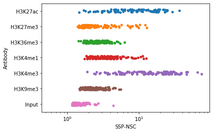

```python
import seaborn as sns
ax = plt.subplots(figsize=(6, 4))
ax = sns.stripplot(data=df, x='SSP-NSC', y='Antibody')
ax.set_xscale("log")
```

# 相関係数ヒートマップ

```python
grouped = df.groupby('Antibody')
grouped.corr()
```

| Antibody |  | total read number | depth | Genome coverage | GC | FRiP (MACS2) | FRiP (DROMPA) | SSP-NSC | SSP-RSC | Background uniformity | FCS | Q-RSC | JSD | PPQT-NSC | PPQT-RSC | PPQT-Qtag | MACS2 peaks | DROMPA peaks |
| --- | --- | --- | --- | --- | --- | --- | --- | --- | --- | --- | --- | --- | --- | --- | --- | --- | --- | --- |
| H3K27ac | total read number | 1.000000 | 0.998847 | 0.719893 | -0.066607 | -0.201205 | -0.304718 | -0.406543 | 0.028031 | 0.250087 | -0.401598 | 0.002982 | -0.172615 | -0.386732 | 0.025022 | -0.121911 | 0.276096 | -0.231471 |
|  | depth | 0.998847 | 1.000000 | 0.734263 | -0.070680 | -0.216386 | -0.319192 | -0.420039 | 0.025034 | 0.257095 | -0.407826 | -0.005381 | -0.187597 | -0.405131 | 0.017782 | -0.136821 | 0.268792 | -0.243702 |
|  | Genome coverage | 0.719893 | 0.734263 | 1.000000 | -0.413049 | -0.731874 | -0.774556 | -0.767231 | -0.103337 | 0.722281 | -0.517755 | -0.184564 | -0.717931 | -0.774900 | -0.180708 | -0.371048 | -0.146789 | -0.674709 |
|  | GC | -0.066607 | -0.070680 | -0.413049 | 1.000000 | 0.270713 | 0.272195 | 0.198826 | 0.057660 | -0.683808 | 0.032965 | -0.077564 | 0.316489 | 0.357797 | 0.045316 | 0.108329 | 0.180271 | 0.312441 |
|  | FRiP (MACS2) | -0.201205 | -0.216386 | -0.731874 | 0.270713 | 1.000000 | 0.973608 | 0.842137 | -0.041859 | -0.694032 | 0.616266 | 0.127794 | 0.986195 | 0.795425 | 0.108844 | 0.280406 | 0.470390 | 0.876782 |
| ... | ... | ... | ... | ... | ... | ... | ... | ... | ... | ... | ... | ... | ... | ... | ... | ... | ... | ... |
| Input | PPQT-NSC | -0.277464 | -0.276897 | -0.496787 | 0.350920 | 0.633990 | 0.388578 | 0.985806 | 0.675682 | -0.396362 | 0.278397 | 0.657941 | 0.628065 | 1.000000 | 0.676311 | 0.657320 | 0.597024 | 0.219019 |
|  | PPQT-RSC | 0.026572 | 0.028630 | -0.112760 | 0.059804 | 0.158983 | 0.019429 | 0.588058 | 0.991745 | -0.124800 | -0.099818 | 0.983206 | 0.258824 | 0.676311 | 1.000000 | 0.677432 | 0.208315 | -0.020252 |
|  | PPQT-Qtag | 0.015179 | 0.016749 | -0.153382 | 0.260318 | 0.310403 | 0.017751 | 0.582363 | 0.697868 | -0.365024 | -0.149895 | 0.576006 | 0.495624 | 0.657320 | 0.677432 | 1.000000 | 0.355338 | -0.051814 |
|  | MACS2 peaks | -0.030805 | -0.031865 | -0.240009 | 0.527096 | 0.909431 | 0.206994 | 0.609934 | 0.204747 | -0.618614 | 0.167063 | 0.165941 | 0.759092 | 0.597024 | 0.208315 | 0.355338 | 1.000000 | 0.047557 |
|  | DROMPA peaks | -0.551208 | -0.551993 | -0.683402 | 0.072381 | 0.118879 | 0.956623 | 0.299337 | -0.046680 | 0.049496 | 0.710807 | 0.012582 | -0.129057 | 0.219019 | -0.020252 | -0.051814 | 0.047557 | 1.000000 |

119 rows × 17 columns

```python
grouped["SSP-NSC", "DROMPA peaks", "FRiP (MACS2)"].corr()
```

| Antibody |  | SSP-NSC | DROMPA peaks | FRiP (MACS2) |
| --- | --- | --- | --- | --- |
| H3K27ac | SSP-NSC | 1.000000 | 0.584693 | 0.842137 |
|  | DROMPA peaks | 0.584693 | 1.000000 | 0.876782 |
|  | FRiP (MACS2) | 0.842137 | 0.876782 | 1.000000 |
| H3K27me3 | SSP-NSC | 1.000000 | 0.617427 | 0.592820 |
|  | DROMPA peaks | 0.617427 | 1.000000 | 0.575153 |
|  | FRiP (MACS2) | 0.592820 | 0.575153 | 1.000000 |
| H3K36me3 | SSP-NSC | 1.000000 | 0.833103 | 0.775065 |
|  | DROMPA peaks | 0.833103 | 1.000000 | 0.789861 |
|  | FRiP (MACS2) | 0.775065 | 0.789861 | 1.000000 |
| H3K4me1 | SSP-NSC | 1.000000 | 0.769464 | 0.820780 |
|  | DROMPA peaks | 0.769464 | 1.000000 | 0.795492 |
|  | FRiP (MACS2) | 0.820780 | 0.795492 | 1.000000 |
| H3K4me3 | SSP-NSC | 1.000000 | 0.468433 | 0.907888 |
|  | DROMPA peaks | 0.468433 | 1.000000 | 0.637416 |
|  | FRiP (MACS2) | 0.907888 | 0.637416 | 1.000000 |
| H3K9me3 | SSP-NSC | 1.000000 | 0.757275 | 0.618904 |
|  | DROMPA peaks | 0.757275 | 1.000000 | 0.617150 |
|  | FRiP (MACS2) | 0.618904 | 0.617150 | 1.000000 |
| Input | SSP-NSC | 1.000000 | 0.299337 | 0.677711 |
|  | DROMPA peaks | 0.299337 | 1.000000 | 0.118879 |
|  | FRiP (MACS2) | 0.677711 | 0.118879 | 1.000000 |

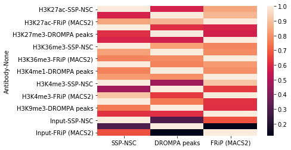

```python
import seaborn as sns

sns.heatmap(grouped["SSP-NSC", "DROMPA peaks", "FRiP (MACS2)"].corr())
```

### groupbyを使うとわかりづらいので、H3K27acだけを使って描いてみる

```python
df_27ac = df[df['Antibody'] == 'H3K27ac']
df_27ac
```

|  | Cell | Antibody | total read number | nonredundant read | redundant read | complexity | depth | Genome coverage | GC | FRiP (MACS2) | ... | SSP-RSC | Background uniformity | FCS | Q-RSC | JSD | PPQT-NSC | PPQT-RSC | PPQT-Qtag | MACS2 peaks | DROMPA peaks |
| --- | --- | --- | --- | --- | --- | --- | --- | --- | --- | --- | --- | --- | --- | --- | --- | --- | --- | --- | --- | --- | --- |
| 0 | E003 | H3K27ac | 21502554 | 21391238 (99.5%) | 111316 (0.5%) | 0.998 | 1.26 | 0.68 | 49 | 0.2021 | ... | 1.36314 | 1.092530 | 0.496900 | 1.742 | 0.360201 | 1.221092 | 1.526650 | 2.0 | 68611 | 22397 |
| 1 | E004 | H3K27ac | 30000000 | 29706394 (99.0%) | 293606 (1.0%) | 0.997 | 1.75 | 0.74 | 52 | 0.2090 | ... | 1.18426 | 1.064700 | 0.431716 | 1.394 | 0.367367 | 1.168355 | 1.281552 | 1.0 | 78944 | 23341 |
| 2 | E005 | H3K27ac | 30000000 | 29698612 (99.0%) | 301388 (1.0%) | 0.997 | 1.75 | 0.74 | 51 | 0.1965 | ... | 1.09821 | 1.042630 | 0.445636 | 1.190 | 0.362768 | 1.157160 | 1.084254 | 1.0 | 68912 | 21516 |
| 3 | E006 | H3K27ac | 30000000 | 29744493 (99.1%) | 255507 (0.9%) | 0.997 | 1.75 | 0.76 | 50 | 0.2292 | ... | 1.20324 | 1.093180 | 0.454843 | 1.435 | 0.362597 | 1.180057 | 1.327205 | 1.0 | 81094 | 26560 |
| 4 | E007 | H3K27ac | 30000000 | 29623085 (98.7%) | 376915 (1.3%) | 0.995 | 1.75 | 0.80 | 49 | 0.0637 | ... | 1.04967 | 1.104720 | 0.234771 | 1.084 | 0.276481 | 1.070251 | 0.924231 | 0.0 | 25710 | 7510 |
| ... | ... | ... | ... | ... | ... | ... | ... | ... | ... | ... | ... | ... | ... | ... | ... | ... | ... | ... | ... | ... | ... |
| 93 | E125 | H3K27ac | 21925355 | 21925355 (100.0%) | 0 (0.0%) | 1 | 1.29 | 0.55 | 47 | 0.4982 | ... | 1.18086 | 1.053610 | 0.570702 | 1.453 | 0.520167 | 1.296648 | 1.000000 | NaN | 88414 | 39469 |
| 94 | E126 | H3K27ac | 30000000 | 30000000 (100.0%) | 0 (0.0%) | 1 | 1.77 | 0.75 | 46 | 0.2257 | ... | 1.20053 | 1.062260 | 0.506667 | 1.513 | 0.404147 | 1.190400 | 1.379748 | 1.0 | 58468 | 26767 |
| 95 | E127 | H3K27ac | 22517166 | 22517166 (100.0%) | 0 (0.0%) | 1 | 1.33 | 0.48 | 51 | 0.5948 | ... | 1.18060 | 0.954189 | 0.526452 | 1.474 | 0.578012 | 1.585941 | 1.310799 | 1.0 | 81545 | 42317 |
| 96 | E128 | H3K27ac | 15453737 | 15453737 (100.0%) | 0 (0.0%) | 1 | 0.91 | 0.44 | 50 | 0.4476 | ... | 1.21529 | 0.980555 | 0.577782 | 1.549 | 0.504857 | 1.505624 | 1.367879 | 1.0 | 64260 | 39790 |
| 97 | E129 | H3K27ac | 30000000 | 30000000 (100.0%) | 0 (0.0%) | 1 | 1.77 | 0.65 | 47 | 0.4459 | ... | 1.13918 | 1.023390 | 0.485493 | 1.449 | 0.488734 | 1.285707 | 1.000000 | NaN | 116631 | 38876 |

98 rows × 22 columns

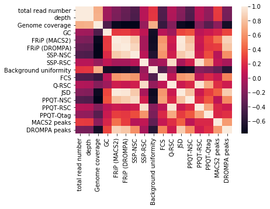

```python
sns.heatmap(df_27ac.corr())
```

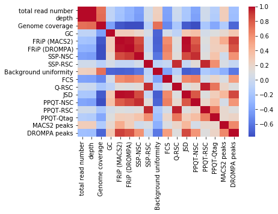

```python
# color paletteを変更
cmap = sns.color_palette("coolwarm", 200)
sns.heatmap(df_27ac.corr(), cmap=cmap)
```

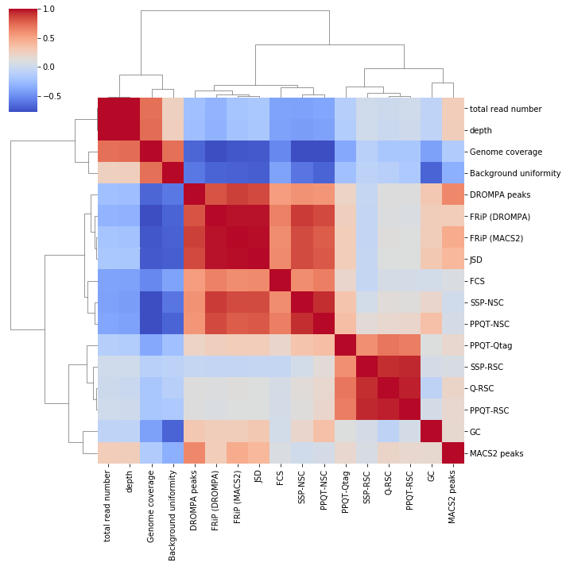

```python
sns.clustermap(df_27ac.corr(), method='ward', cmap=cmap)
```

## ここから、お題について

```python
# お題１：下の図を作成するコードを考える。
```

- こちらを参考に行った

https://matplotlib.org/3.3.2/gallery/units/bar_unit_demo.html#sphx-glr-gallery-units-bar-unit-demo-py

- こちらも参考になりました

https://stackoverrun.com/ja/q/12788276

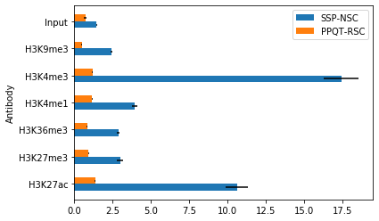

```python
# プロットするグループの数を、N =に入れておく
N = 7
nsc_means = group_nsc.mean() # SSP_NSCのmeanを代入、groupbyで作った値を使用
sem_SSP = group_nsc.std()/np.sqrt(group_nsc.count()) # SSP_NSCのsemを計算、groupbyで作ったstdをrout(n)で割る

fig, ax = plt.subplots() # figureの枠を作る

ind = np.arange(N)    # the x locations for the groups
# このindの意味？ indのなかみは、初項が0で公差が1の等差数列を要素とするndarray[0, 1, 2, 3, 4, 5, 6]
width = 0.25         # the width of the bars
ax.barh(ind, nsc_means, width, xerr=sem_SSP, label='SSP-NSC') # barhで横棒グラフを描画
# indで指定した場所に、nsc_meansを、widthの幅で、エラーバーはsem_SSPで書く。ラベルは"SSP-NSC"

ppqt_means = group_ppqt.mean() # PPQT_RSCのmeanを代入
sem_PPQT = group_ppqt.std()/np.sqrt(group_ppqt.count()) # PPQT_RSCのsemを計算

ax.barh(ind + width, ppqt_means, width,  xerr=sem_PPQT,
       label='PPQT-RSC') #ind+widthで、widthの分ずらした場所にプロットする、なぜこれでいけるのか。
# ind + widthで指定した場所に、ppqt_meansを、widthの幅で、エラーバーはsem_PPQTで書く。ラベルは"PPQT_RSC"

ax.set_yticks(ind + width / 2) # y軸の印を付ける場所は、ind + width /2の場所。つまり、ふたつの真ん中。
ax.set_yticklabels(pd.unique(df["Antibody"])) # y軸のtickごとのラベルは、dfのAntibodyのユニークなもの。
ax.set_ylabel('Antibody') # y軸のラベル指定。

ax.legend() # legendを表示
ax.autoscale_view() # 軸のスケールを自動的に設定

plt.show()
```

```python
# お題２；お題１で作った図について、エラーバーを標準誤差（SEM）から信頼区間（CI）に変更する。
```

- こちらを参考にしました。 https://obgyn.jp/ci/

```python
from scipy import stats

# t分布を仮定した場合の信頼区間
ci_SSP = stats.t.interval(alpha = 0.95,          # 信頼区間
                      df = group_nsc.count()-1, # 自由度
                      loc = group_nsc.mean(),            # 標本平均
                      scale = group_nsc.sem())           # 標準誤差

ci_PPQT = stats.t.interval(alpha = 0.95,          # 信頼区間
                      df = group_ppqt.count()-1, # 自由度
                      loc = group_ppqt.mean(),            # 標本平均
                      scale = group_ppqt.sem())           # 標準誤差
```

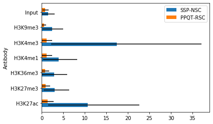

```python
N = 7
nsc_means = group_nsc.mean() # SSP_NSCのmeanを代入、groupbyで作った値を使用

fig, ax = plt.subplots() # figureの枠を作る

ind = np.arange(N)
width = 0.25
ax.barh(ind, nsc_means, width, xerr=ci_SSP, label='SSP-NSC')
# xerrをciに変更

ppqt_means = group_ppqt.mean() # PPQT_RSCのmeanを代入

ax.barh(ind + width, ppqt_means, width,  xerr=ci_PPQT,
       label='PPQT-RSC')

ax.set_yticks(ind + width / 2)
ax.set_yticklabels(pd.unique(df["Antibody"]))
ax.set_ylabel('Antibody')

ax.legend() # legendを表示
ax.autoscale_view() # 軸のスケールを自動的に設定

plt.show()
```

```python
# お題３：logスケールboxplotで外れ値を非表示にするオプションを調べる。
```

- こちらを参考に行った。 https://www.haya-programming.com/entry/2019/10/07/202416

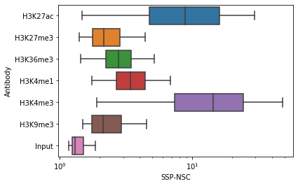

```python
f, ax = plt.subplots(figsize=(6, 4))
ax.set_xscale("log")
sns.boxplot(data=df, x='SSP-NSC', y='Antibody', sym="") # 非表示にするだけで、検出は行っている
```

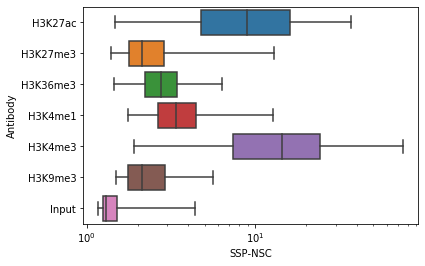

```python
f, ax = plt.subplots(figsize=(6, 4))
ax.set_xscale("log")
sns.boxplot(data=df, x='SSP-NSC', y='Antibody', whis="range") # 検出自体を行わない、ひげが長くなる
```

```python
# 問：外れ値を表示した方がよい場合と、非表示にした方がよい場合はそれぞれどのようなケースか。
```

- サンプル数が多く、見た目的に気になるほどの外れ値が出てしまう場合に、見た目を整える意味で非表示にする。
- サンプル数が少なく、外れ値にも意味がある場合には外れ値を表示する。

```python
# お題４：logスケールboxplotをviolin plotに変更する。
```

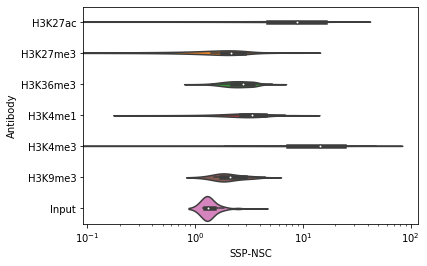

```python
f, ax = plt.subplots(figsize=(6, 4))
ax.set_xscale("log")
sns.violinplot(data=df, x='SSP-NSC', y='Antibody')
```

```python
# 問：boxplotが望ましい場合とviolin plotが望ましい場合の例を考える。
```

- 今回のように分布の幅が広く、密度にあまり差がない場合、boxplotが見やすいので望ましい。

```python
# お題５：SSP_Fig2Bを自分で作成してみる。
```

- こちらを参考に https://qiita.com/txt_only/items/b954e26be739bee5621e

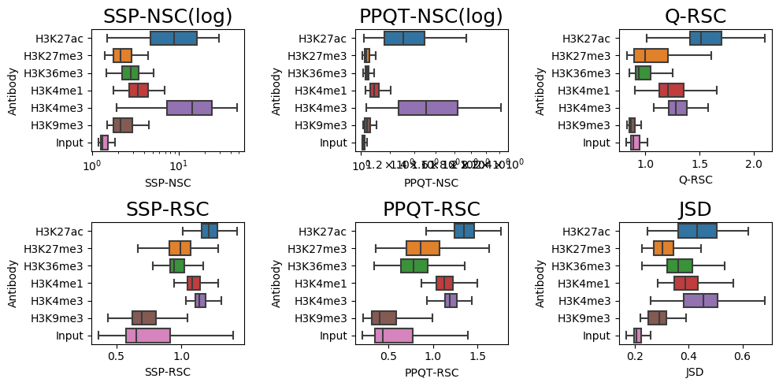

```python
# figureを生成する

fig = plt.figure(figsize=(10, 5), dpi=100, facecolor='w', linewidth=0, edgecolor='w')

# 2x3の1番目
ax1 = fig.add_subplot(2, 3, 1)
ax1.set_title('SSP-NSC(log)', fontsize=18)  # グラフタイトル
ax1.set_xscale("log")
# ax1.set_xlabel("")
sns.boxplot(data=df, x='SSP-NSC', y='Antibody', sym="", ax = ax1)

# 2x3の2番目
ax2 = fig.add_subplot(2, 3, 2)
ax2.set_title('PPQT-NSC(log)', fontsize=18)  # グラフタイトル
ax2.set_xscale("log")
sns.boxplot(data=df, x='PPQT-NSC', y='Antibody', sym="", ax = ax2)

# 2x3の3番目
ax3 = fig.add_subplot(2, 3, 3)
ax3.set_title('Q-RSC', fontsize=18)  # グラフタイトル
sns.boxplot(data=df, x='Q-RSC', y='Antibody', sym="", ax = ax3)

# 2x3の4番目
ax4 = fig.add_subplot(2, 3, 4)
ax4.set_title('SSP-RSC', fontsize=18)  # グラフタイトル
sns.boxplot(data=df, x='SSP-RSC', y='Antibody', sym="", ax = ax4)

# 2x3の5番目
ax5 = fig.add_subplot(2, 3, 5)
ax5.set_title('PPQT-RSC', fontsize=18)  # グラフタイトル
sns.boxplot(data=df, x='PPQT-RSC', y='Antibody', sym="", ax = ax5)


# 2x3の6番目
ax6 = fig.add_subplot(2, 3, 6)
ax6.set_title('JSD', fontsize=18)  # グラフタイトル
sns.boxplot(data=df, x='JSD', y='Antibody', sym="", ax = ax6)

# 表示する

plt.tight_layout() # 文字の重なりを解消する呪文
plt.show()
```

### 小さな問題点

- x_labelが消せない
- xの値を上にできない
- 色も変えないといけない
- y_labelも２個だけでいいのに、全部ついてしまう
- PPQT-NSC(log)のx軸の値がつぶれている

```python
# お題６：H3K36me3, Input についてそれぞれ相関係数ヒートマップを描き、Antibodyごとの傾向の違いを観察する。
```

```python
df_36me3 = df[df['Antibody'] == 'H3K36me3']
df_36me3
```

|  | Cell | Antibody | total read number | nonredundant read | redundant read | complexity | depth | Genome coverage | GC | FRiP (MACS2) | ... | SSP-RSC | Background uniformity | FCS | Q-RSC | JSD | PPQT-NSC | PPQT-RSC | PPQT-Qtag | MACS2 peaks | DROMPA peaks |
| --- | --- | --- | --- | --- | --- | --- | --- | --- | --- | --- | --- | --- | --- | --- | --- | --- | --- | --- | --- | --- | --- |
| 225 | E001 | H3K36me3 | 20540560 | 20487263 (99.7%) | 53297 (0.3%) | 0.999 | 1.21 | 0.71 | 47 | 0.2188 | ... | 1.325200 | 1.100720 | 0.116199 | 1.707 | 0.290656 | 1.056173 | 1.159956 | 1.0 | 85046 | 8297 |
| 226 | E002 | H3K36me3 | 9533889 | 9533889 (100.0%) | 0 (0.0%) | (1.000) | 0.56 | 0.52 | 44 | 0.0360 | ... | 1.536430 | 1.137700 | 0.070243 | 1.943 | 0.227497 | 1.047472 | 1.762133 | 2.0 | 17285 | 6814 |
| 227 | E003 | H3K36me3 | 30000000 | 29707465 (99.0%) | 292535 (1.0%) | 0.997 | 1.75 | 0.79 | 48 | 0.3343 | ... | 0.974438 | 1.053270 | 0.278828 | 0.954 | 0.351959 | 1.047654 | 0.821064 | 0.0 | 69184 | 24510 |
| 228 | E004 | H3K36me3 | 30000000 | 30000000 (100.0%) | 0 (0.0%) | 1 | 1.77 | 0.82 | 48 | 0.0004 | ... | 1.196310 | 1.133120 | 0.030946 | 1.225 | 0.236678 | 1.027986 | 1.168752 | 1.0 | 321 | 1 |
| 229 | E005 | H3K36me3 | 30000000 | 29634257 (98.8%) | 365743 (1.2%) | 0.996 | 1.75 | 0.62 | 60 | 0.4054 | ... | 1.201820 | 0.849386 | 0.319807 | 1.492 | 0.410606 | 1.113926 | 1.348582 | 1.0 | 100350 | 17536 |
| ... | ... | ... | ... | ... | ... | ... | ... | ... | ... | ... | ... | ... | ... | ... | ... | ... | ... | ... | ... | ... | ... |
| 347 | E125 | H3K36me3 | 26980400 | 26980400 (100.0%) | 0 (0.0%) | 1 | 1.59 | 0.77 | 44 | 0.3003 | ... | 0.864541 | 1.110560 | 0.179487 | 0.897 | 0.328130 | 1.023367 | 0.621833 | 0.0 | 75034 | 9198 |
| 348 | E126 | H3K36me3 | 30000000 | 30000000 (100.0%) | 0 (0.0%) | 1 | 1.77 | 0.81 | 43 | 0.1109 | ... | 0.905866 | 1.112730 | 0.126902 | 0.937 | 0.313832 | 1.020898 | 0.745045 | 0.0 | 37995 | 4921 |
| 349 | E127 | H3K36me3 | 19064897 | 19064897 (100.0%) | 0 (0.0%) | 1 | 1.12 | 0.62 | 47 | 0.4308 | ... | 0.875450 | 1.010770 | 0.199790 | 0.881 | 0.364627 | 1.028735 | 0.617971 | 0.0 | 93682 | 27725 |
| 350 | E128 | H3K36me3 | 22059290 | 22059290 (100.0%) | 0 (0.0%) | 1 | 1.30 | 0.69 | 47 | 0.1909 | ... | 1.025040 | 1.048440 | 0.177197 | 1.085 | 0.343793 | 1.044374 | 1.015002 | 1.0 | 47837 | 25569 |
| 351 | E129 | H3K36me3 | 30000000 | 30000000 (100.0%) | 0 (0.0%) | 1 | 1.77 | 0.76 | 44 | 0.3969 | ... | 0.926605 | 1.087510 | 0.215682 | 0.929 | 0.368170 | 1.028312 | 0.729465 | 0.0 | 75888 | 17450 |

127 rows × 22 columns

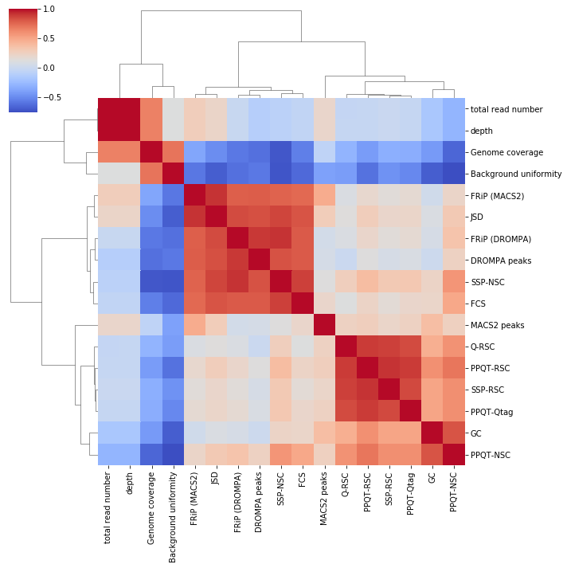

```python
sns.clustermap(df_36me3.corr(), method='ward', cmap=cmap)
```

```python
df_input = df[df['Antibody'] == 'Input']
df_input
```

|  | Cell | Antibody | total read number | nonredundant read | redundant read | complexity | depth | Genome coverage | GC | FRiP (MACS2) | ... | SSP-RSC | Background uniformity | FCS | Q-RSC | JSD | PPQT-NSC | PPQT-RSC | PPQT-Qtag | MACS2 peaks | DROMPA peaks |
| --- | --- | --- | --- | --- | --- | --- | --- | --- | --- | --- | --- | --- | --- | --- | --- | --- | --- | --- | --- | --- | --- |
| 733 | E001 | Input | 30000000 | 29948315 (99.8%) | 51685 (0.2%) | 0.999 | 1.77 | 0.89 | 44 | 0.0016 | ... | 1.145230 | 1.13974 | 0.029437 | 1.122 | 0.202493 | 1.019102 | 1.008519 | 1.0 | 642 | 362 |
| 734 | E002 | Input | 10943655 | 10943655 (100.0%) | 0 (0.0%) | 1 | 0.65 | 0.50 | 43 | 0.0491 | ... | 2.371590 | 1.12947 | 0.162744 | 3.487 | 0.272489 | 1.176076 | 2.990425 | 2.0 | 26410 | 130721 |
| 735 | E003 | Input | 30000000 | 29762951 (99.2%) | 237049 (0.8%) | 0.997 | 1.76 | 0.88 | 46 | 0.0023 | ... | 1.396810 | 1.14691 | 0.044707 | 1.475 | 0.211502 | 1.028557 | 1.046402 | 1.0 | 1113 | 620 |
| 736 | E004 | Input | 30000000 | 29854977 (99.5%) | 145023 (0.5%) | 0.998 | 1.76 | 0.85 | 51 | 0.0023 | ... | 1.093980 | 1.11835 | 0.030154 | 1.071 | 0.240959 | 1.023133 | 0.912595 | 0.0 | 1629 | 1092 |
| 737 | E005 | Input | 30000000 | 29864070 (99.5%) | 135930 (0.5%) | 0.998 | 1.76 | 0.86 | 51 | 0.0016 | ... | 0.757194 | 1.11870 | 0.035659 | 0.938 | 0.235839 | 1.021022 | 0.593684 | 0.0 | 575 | 1078 |
| ... | ... | ... | ... | ... | ... | ... | ... | ... | ... | ... | ... | ... | ... | ... | ... | ... | ... | ... | ... | ... | ... |
| 855 | E125 | Input | 30000000 | 30000000 (100.0%) | 0 (0.0%) | 1 | 1.77 | 0.87 | 45 | 0.0013 | ... | 0.957233 | 1.14108 | 0.039721 | 0.920 | 0.212654 | 1.016054 | 0.857049 | 0.0 | 379 | 744 |
| 856 | E126 | Input | 16806474 | 16806474 (100.0%) | 0 (0.0%) | 1 | 0.99 | 0.70 | 45 | 0.0042 | ... | 1.141200 | 1.15005 | 0.152653 | 1.234 | 0.233434 | 1.066987 | 1.197045 | 1.0 | 836 | 2008 |
| 857 | E127 | Input | 20364549 | 20364549 (100.0%) | 0 (0.0%) | 1 | 1.20 | 0.80 | 45 | 0.0037 | ... | 0.485702 | 1.15766 | 0.204078 | 0.850 | 0.210048 | 1.012264 | 0.268751 | -1.0 | 550 | 2092 |
| 858 | E128 | Input | 12868984 | 12868984 (100.0%) | 0 (0.0%) | 1 | 0.76 | 0.66 | 45 | 0.0029 | ... | 0.407191 | 1.14904 | 0.146981 | 0.860 | 0.210967 | 1.013456 | 0.238210 | -2.0 | 335 | 8823 |
| 859 | E129 | Input | 30000000 | 30000000 (100.0%) | 0 (0.0%) | 1 | 1.77 | 0.88 | 43 | 0.0017 | ... | 0.699353 | 1.13843 | 0.057480 | 0.887 | 0.206593 | 1.011365 | 0.543952 | 0.0 | 410 | 866 |

127 rows × 22 columns

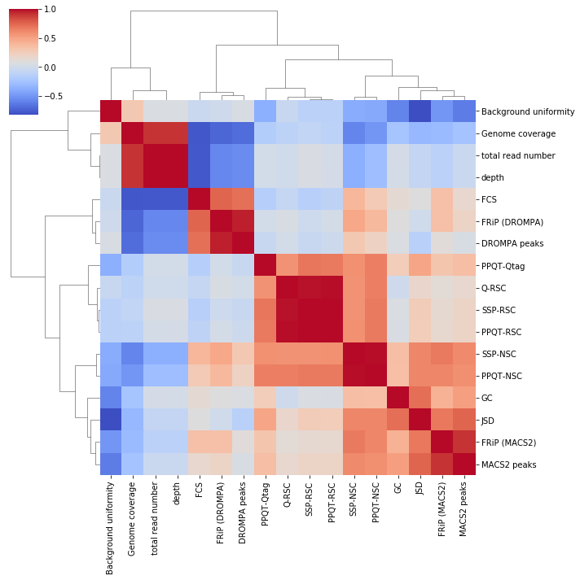

```python
sns.clustermap(df_input.corr(), method='ward', cmap=cmap)
```

- 各項目の示す意味がわかっていないので、考察できない。。。

## 以下は作業時に試行錯誤したもの。

## 不要なので無視してください。

```python
# SSP_NSCのgroupbyオブジェクトをデータフレームにする。
SSP_NSC_grouped = grouped["SSP-NSC"].describe().reset_index()

# 確認
SSP_NSC_grouped
```

|  | Antibody | count | mean | std | min | 25% | 50% | 75% | max |
| --- | --- | --- | --- | --- | --- | --- | --- | --- | --- |
| 0 | H3K27ac | 98.0 | 10.628491 | 7.187384 | 1.47458 | 4.726793 | 8.85960 | 16.109950 | 36.74470 |
| 1 | H3K27me3 | 127.0 | 3.001507 | 2.275501 | 1.40126 | 1.775215 | 2.13453 | 2.853655 | 12.89230 |
| 2 | H3K36me3 | 127.0 | 2.878950 | 0.857118 | 1.44237 | 2.217845 | 2.76327 | 3.445625 | 6.33647 |
| 3 | H3K4me1 | 127.0 | 3.958322 | 2.075257 | 1.74950 | 2.658055 | 3.39133 | 4.417200 | 12.68960 |
| 4 | H3K4me3 | 127.0 | 17.431514 | 12.691163 | 1.90685 | 7.329880 | 14.35650 | 24.263200 | 74.84710 |
| 5 | H3K9me3 | 127.0 | 2.426743 | 0.870322 | 1.48843 | 1.747070 | 2.12857 | 2.901935 | 5.60866 |
| 6 | Input | 127.0 | 1.451826 | 0.398561 | 1.17248 | 1.243730 | 1.30674 | 1.506045 | 4.41231 |

```python
SSP_NSC_grouped["count"]
```

```
0     98.0
1    127.0
2    127.0
3    127.0
4    127.0
5    127.0
6    127.0
Name: count, dtype: float64
```

```python
# 使う部分だけ取り出す
SSP_use = SSP_NSC_grouped.loc[:,['Antibody','mean']]
```

```python
# from groupby object to dataframe
PPQT_RSC_grouped = grouped["PPQT-RSC"].describe().reset_index()

# confirmation
PPQT_RSC_grouped
```

|  | Antibody | count | mean | std | min | 25% | 50% | 75% | max |
| --- | --- | --- | --- | --- | --- | --- | --- | --- | --- |
| 0 | H3K27ac | 98.0 | 1.380666 | 0.272690 | 0.924231 | 1.243776 | 1.350993 | 1.464006 | 2.976173 |
| 1 | H3K27me3 | 127.0 | 0.948663 | 0.424310 | 0.357285 | 0.698629 | 0.861536 | 1.075640 | 2.876011 |
| 2 | H3K36me3 | 127.0 | 0.837057 | 0.289518 | 0.336559 | 0.637540 | 0.780760 | 0.940051 | 1.817041 |
| 3 | H3K4me1 | 127.0 | 1.164169 | 0.216447 | 0.640474 | 1.038950 | 1.129770 | 1.224185 | 2.283974 |
| 4 | H3K4me3 | 127.0 | 1.182446 | 0.141500 | 0.497988 | 1.133702 | 1.184759 | 1.271158 | 1.579291 |
| 5 | H3K9me3 | 127.0 | 0.508917 | 0.300367 | 0.211308 | 0.308324 | 0.400124 | 0.583535 | 1.878076 |
| 6 | Input | 127.0 | 0.736335 | 1.063111 | 0.201614 | 0.343113 | 0.436471 | 0.773685 | 8.825757 |

```python
# 使う部分だけ取り出す
PPQT_use = PPQT_RSC_grouped.loc[:,['mean']]
```

```python
# 使う部分だけ横に結合する
concat_df_v = pd.concat([SSP_use, PPQT_use], axis=1)
# column nameを付け直す
concat_df_v.columns = ['Antibody', 'SSP_NSC', 'PPQT_RSC']
# Antibodyをindexにする
concat_df_v = concat_df_v .set_index('Antibody')
# 確認
concat_df_v
```

| Antibody | SSP_NSC | PPQT_RSC |
| --- | --- | --- |
| H3K27ac | 10.628491 | 1.380666 |
| H3K27me3 | 3.001507 | 0.948663 |
| H3K36me3 | 2.878950 | 0.837057 |
| H3K4me1 | 3.958322 | 1.164169 |
| H3K4me3 | 17.431514 | 1.182446 |
| H3K9me3 | 2.426743 | 0.508917 |
| Input | 1.451826 | 0.736335 |

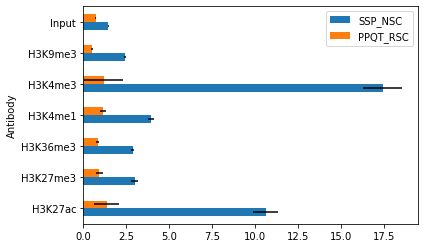

```python
# 描画
concat_df_v.plot(kind='barh', legend=True, xerr = sem_SSP)
# semをどないしよ
# CIもつけなあかん
```

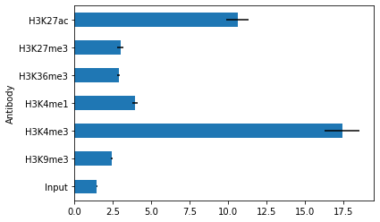

```python
sem_SSP = group_nsc.std()/np.sqrt(group_nsc.count())
ax1 = group_nsc.mean().plot(kind='barh', xerr=sem_SSP)
ax1.invert_yaxis()
```

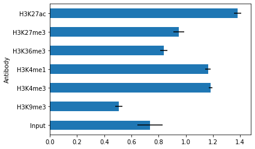

```python
group_ppqt = grouped["PPQT-RSC"]
sem_PPQT = group_ppqt.std()/np.sqrt(group_ppqt.count())
ax2 = group_ppqt.mean().plot(kind='barh', xerr=sem_PPQT)
ax2.invert_yaxis()
```

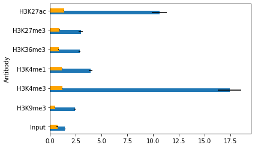

```python
fig = plt.figure()
ax = group_nsc.mean().plot(kind='barh', xerr=sem_SSP, align = 'edge', width = 0.2)
ax = group_ppqt.mean().plot(kind='barh', xerr=sem_PPQT, align = 'center',  width = 0.2, color = "orange")
ax.invert_yaxis()
# alignの設定は'edge'か'center'、というわけで重なってしまう。
```